# Chinese

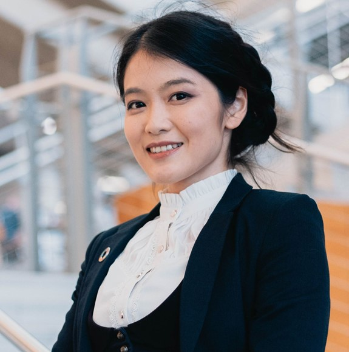

我叫郑李（笔名李子），目前是美国佐治亚理工大学历史与社会学系的博士候选人。我的跨专业研究领域专注于技术的社会影响之上，特别是个人科技产品对人们健康观念的影响。我主要研究中国的健康科技市场、产品和用户，以及与这些产品相关的社会实践。

我本科毕业于北京大学，专业是国际政治以及社会学，之后在伦敦政治经济学院获取硕士学位。毕业之后，我在科学传播领域积累了丰富的工作经验，作为科学作者、社交媒体意见领袖活跃。目前我主要为中文各大媒体撰写与科学、技术与社会相关的深度或评论文章。

业余时间，我经常出没于各大国家公园观鸟，或者和朋友一起攀岩。

# Research

[figure not shown]

My research primarily focuses on the personal technologies and its impact on health. I look at various kinds of wearables and the trends of self-tracking/self-quantification, and see how the design, human-machine interaction, collection of bodily data shapes the perception of healthy life.

# Teaching

[figure not shown]

I enjoy teaching and communicating with students. My mission is to inform and inspire more students (especially those of STEM majors) to think about the societal impact of science and technology, and to raise their awareness of social justice and human well-being.

I teach various level from introductory courses to advanced seminars. I was trained in Center of Teaching and Learning in Georgia Tech and am working towards a teaching certificate.

Courses I have taught or lectured a teaching assistant:

- Introduction to Sociology
- History of Medicine
- Sociology of Health and Illness
- Social Development
- Science and Technology Studies

# Outreach & Engagement

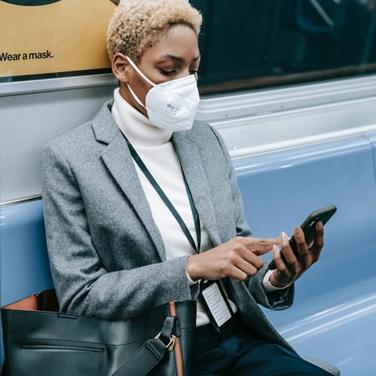

I believe that the knowledge from the academia should be shared with the public with relevancy to the current and ongoing issues. I have years of experience writing for general audience about science and technology, and delivered public speeches and lectures on issues such as pandemic, health and inequality, technology use, etc.

I write research and consulting reports for individuals or businesses on technological and societal impact and how to make sensible communications of them. Contact me for a quote.

I also translated a few well-known books from English to Chinese, namely I Contain Multitude by Ed Yong, and Scientific Revolution by Steven Shapin.